# Traditional Programming vs Machine Learning Diagram

[output not shown]

**Training:** The process of creating machine learning models is called training. This is where a computer uses a set of algorithms to learn about inputs and what distinguishes them from each other.

**Inference:** Once the model is trained, the process of having it recognize or categorize future inputs is called inference.

Support Needed for Traning Models:

A set of APIs for designing the models themselves.

- You can code everything by hand, where you figure out the logic for how a computer can learn and then implement that in code (not recommended)
- You can use built-in *estimators*, which are already-implemented neural networks that you can customize
- Or you can use Keras, a high-level API that allows you to encapsulate common machine learning paradigms in code.

# **Introduction to Types of Data**

## Read in Methods

```python
%%capture
!pip install import_ipynb
import import_ipynb
from google.colab import drive
drive.flush_and_unmount()
drive.mount("mnt")
m = __import__("mnt/MyDrive/Colab Notebooks/Copy of methods")
```

## Data Example

Using micro ct data from OSD-557 as an example:

```python
data=dict()
data['microCT'] = m.read_phenotype_data('557', 'LSDS-1_microCT_MicroCT_Transformed_Reusable_Results')
print('num records: ', len(data['microCT']))
print('treatments: ', set(data['microCT']['Treatment']))
data['microCT'].head()
```

```
num records:  12
treatments:  {'Flight', 'Ground Control', 'Vivarium'}
```

|  | Source Name | Sample Name | Treatment | Ant-Post | Sup-Inf | Retina | Pigment Layer | Choroid | Sclera | Ant-Post.1 | Right-left | Retina.1 | Pigment Layer.1 | Choroid.1 | Sclera.1 |
| --- | --- | --- | --- | --- | --- | --- | --- | --- | --- | --- | --- | --- | --- | --- | --- |
| 0 | F10 | F10_Mouse_Eye | Flight | 1.765000 | 2.044000 | 0.077 | 0.038 | 0.041000 | 0.059000 | 1.748000 | 1.997000 | 0.144000 | 0.051000 | 0.041000 | 0.073000 |
| 1 | F12 | F12_Mouse_Eye | Flight | 1.724000 | 2.028000 | 0.091 | 0.048 | 0.036000 | 0.054000 | 1.720000 | 1.980000 | 0.087000 | 0.041000 | 0.039000 | 0.057000 |
| 2 | F13 | F13_Mouse_Eye | Flight | 1.754333 | 2.043667 | 0.089 | 0.044 | 0.036333 | 0.054333 | 1.750333 | 1.969667 | 0.113667 | 0.053667 | 0.038333 | 0.065333 |
| 3 | F14 | F14_Mouse_Eye | Flight | 1.774000 | 2.059000 | 0.099 | 0.046 | 0.032000 | 0.050000 | 1.783000 | 1.932000 | 0.110000 | 0.069000 | 0.035000 | 0.066000 |
| 4 | V10 | V10_Mouse_Eye | Vivarium | 1.771000 | 2.119000 | 0.145 | 0.076 | 0.083000 | 0.109000 | 1.755000 | 2.089000 | 0.118000 | 0.055000 | 0.061000 | 0.067000 |

## Different Types of Measurement:

- Anterior-Posterior Measurement
- Superior-inferior Measurement
- Retina Measurement
- Pigment layer Measurement
- Choroid Measurement
- Sclera Measurement

### **Anterior-Posterior Measurement**

Plot a box plot and get stats for the Ant-Post field of the micro CT data

for ground and spaceflight samples

```
field:  Ant-Post
excluding samples:  []
{'Ant-Post': {'t-test p-value': 0.14175}}
n flight =  4
n nonflight =  8
```

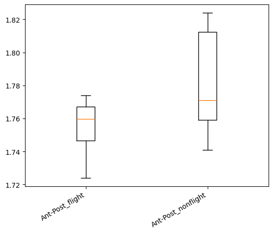

```
field:  Ant-Post.1
excluding samples:  []
{'Ant-Post.1': {'t-test p-value': 0.49605}}
n flight =  4
n nonflight =  8
```

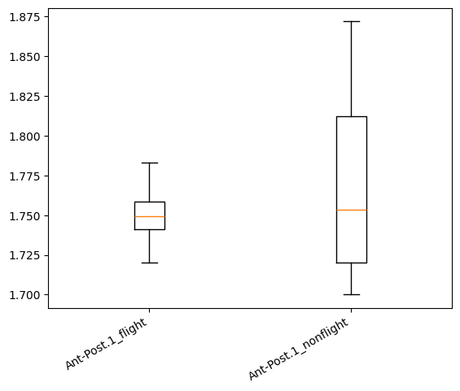

```python
m.plotbox_and_stats(data_=data['microCT'], sample_key='Source Name', field ='Ant-Post', treatment = 'Treatment', space='Flight', exclude_samples=[])
m.plotbox_and_stats(data_=data['microCT'], sample_key='Source Name', field ='Ant-Post.1', treatment = 'Treatment', space='Flight', exclude_samples=[])
```

### **Superior-Inferior Measurement**

Plot a box plot for the Sup-Inf field of the micro CT data for ground and spaceflight samples (note there is no Sup-Inf.1 measurement)

```
field:  Sup-Inf
excluding samples:  []
{'Sup-Inf': {'t-test p-value': 0.52282}}
n flight =  4
n nonflight =  8
```

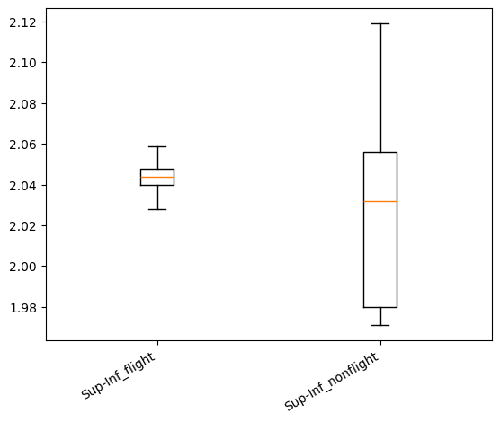

```python
m.plotbox_and_stats(data_=data['microCT'], sample_key = 'Source Name', field='Sup-Inf', treatment='Treatment', space='Flight', exclude_samples=[])
```

### **Retina Measurement**

The `Retina` field is the measurement for the left eye, and the `Retina.1` field is the measurement for the right eye. Plot a box plot for the Retina field of the micro CT data for ground and spaceflight samples

```
field:  Retina
excluding samples:  []
{'Retina': {'t-test p-value': 0.00796}}
n flight =  4
n nonflight =  8
```

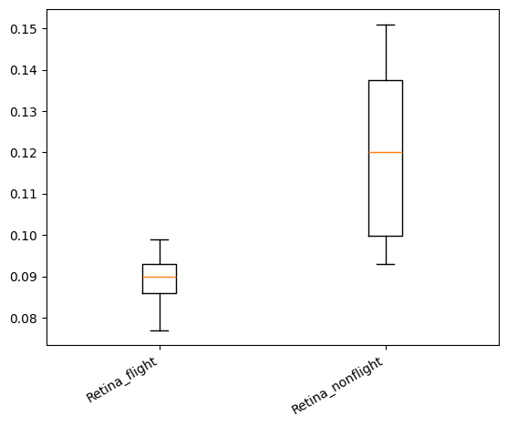

```
field:  Retina.1
excluding samples:  []
{'Retina.1': {'t-test p-value': 0.82328}}
n flight =  4
n nonflight =  8
```

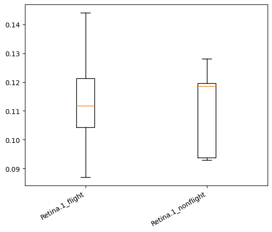

```python
m.plotbox_and_stats(data_=data['microCT'],  sample_key = 'Source Name', field='Retina', treatment='Treatment', space='Flight', exclude_samples=[])
m.plotbox_and_stats(data_=data['microCT'],  sample_key = 'Source Name', field='Retina.1', treatment='Treatment', space='Flight', exclude_samples=[])
```

### **Pigment layer Measurement**

The `Pigment Layer` field is the measurement for the left eye, and the `Pigmen Layer.1` field is the measurement for the right eye. Plot a box plot for the Pigment Layer field of the micro CT data for ground and spaceflight samples

```
field:  Pigment Layer
excluding samples:  []
{'Pigment Layer': {'t-test p-value': 0.01535}}
n flight =  4
n nonflight =  8
```

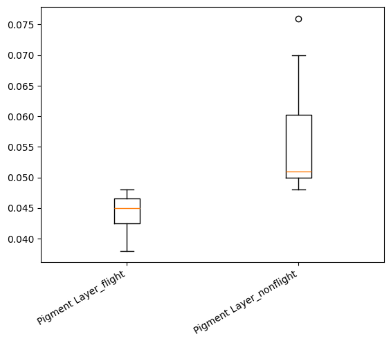

```
field:  Pigment Layer.1
excluding samples:  []
{'Pigment Layer.1': {'t-test p-value': 0.98999}}
n flight =  4
n nonflight =  8
```

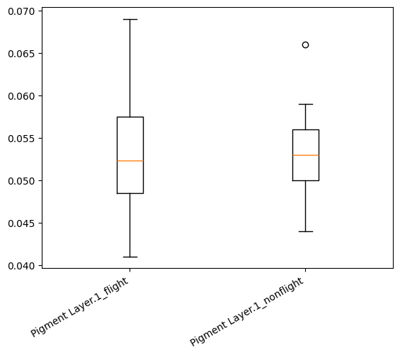

```python
m.plotbox_and_stats(data_=data['microCT'], sample_key = 'Source Name', field='Pigment Layer', treatment='Treatment', space='Flight', exclude_samples=[])
m.plotbox_and_stats(data_=data['microCT'], sample_key = 'Source Name', field='Pigment Layer.1', treatment='Treatment', space='Flight', exclude_samples=[])
```

### **Choroid Measurement**

The Choroid field is the measurement for the left eye, and the Choroid.1 field is the measurement for the right eye. Plot a box plot for the Choroid field of the micro CT data for ground and spaceflight samples

```
field:  Choroid
excluding samples:  []
{'Choroid': {'t-test p-value': 0.01249}}
n flight =  4
n nonflight =  8
```

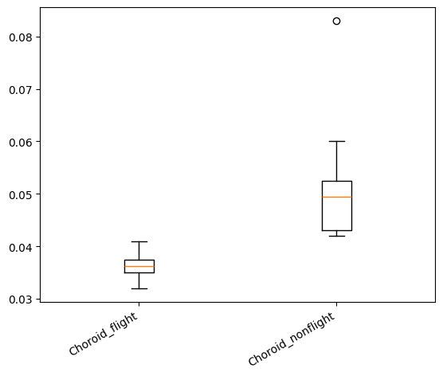

```
field:  Choroid.1
excluding samples:  []
{'Choroid.1': {'t-test p-value': 0.00862}}
n flight =  4
n nonflight =  8
```

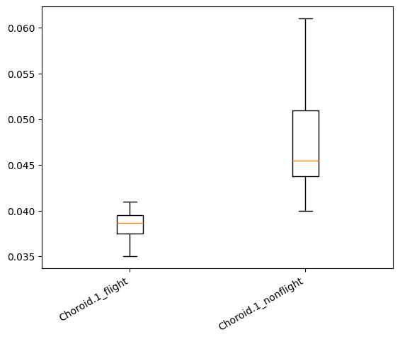

```python
m.plotbox_and_stats(data_=data['microCT'], sample_key = 'Source Name', field='Choroid', treatment='Treatment', space='Flight', exclude_samples=[])
m.plotbox_and_stats(data_=data['microCT'], sample_key = 'Source Name', field='Choroid.1', treatment='Treatment', space='Flight', exclude_samples=[])
```

### **Sclera Measurement**

The `Sclera` field is the measurement for the left eye, and the `Sclera.1` field is the measurement for the right eye. Plot a box plot for the Sclera field of the micro CT data for ground and spaceflight samples

```
field:  Sclera
excluding samples:  []
{'Sclera': {'t-test p-value': 0.0026}}
n flight =  4
n nonflight =  8
```

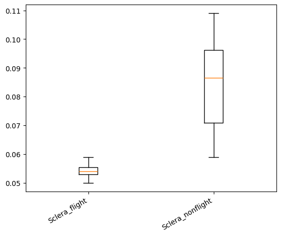

```
field:  Sclera.1
excluding samples:  []
{'Sclera.1': {'t-test p-value': 0.18301}}
n flight =  4
n nonflight =  8
```

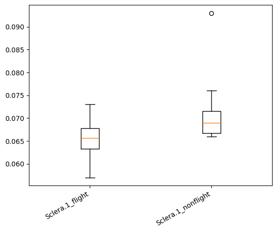

```python
m.plotbox_and_stats(data_=data['microCT'], sample_key = 'Source Name', field='Sclera', treatment='Treatment', space='Flight', exclude_samples=[])
m.plotbox_and_stats(data_=data['microCT'], sample_key = 'Source Name', field='Sclera.1', treatment='Treatment', space='Flight', exclude_samples=[])
```